# Discrete Random Variables

# 2.1 Basic Concepts

## Discrete context

A random variable is a function that assigns a real-number to each outcome of a random experiment.

This happens naturally in many experiments.

- The outcome of rolling a six-sided die.
- The number of home runs hit by a baseball player in a season.

## More discrete context

We can assign numbers to the outcomes of any experiment even when the outcomes aren’t naturally numerical.

- When flipping a coin, we can assign a 1 to a head and a -1 to a tail.
- When throwing a dart at a dartboard, we assign the value 50 to a bullseye. Hitting certain sections of the board doubles or triples a number.

## Visualization of a random variable

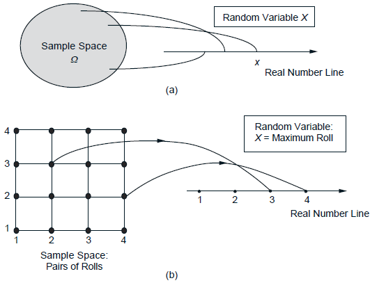

Visualization of a random variable

## Random variable examples

We create a sequence of 5 coin tosses and record the outcome.

- The sequence of heads and tails aren’t a random variable.
- If we assign a number to each outcome (perhaps the number of heads out of 5 coins), then that is a random variable.

## Random variable examples

We roll two die. Random variables include:

- The sum of the two die rolls.
- The number of sixes observed from the two die rolls.

## Random variable examples

We transmit a message. Random variables include:

- The length of time needed to complete the transmission.
- The number of errors in the message transmission.
- The transmission time delay needed to receive the transmission.

## Main concepts related to a random variable

- A random variable is a real-valued function of the outcome of an experiment.
- A function of a random variable defines another random variable.
- The **mean** and **variance** of a random variable are characteristics commonly used to describe the behavior of the random variable.

## More main concepts related to a random variable

- A random variable can be **conditioned** on an event or another random variable.
- Random variables can be **independent** of other random variables or events.

## Concepts related to discrete random variables

A **discrete** random variable is a random variable that can take only finite or countably infinite number of values.

A discrete random variable has an associated **probability mass function (pmf)**, which gives the probability of each numerical value that the random variable can take.

A function of a discrete random variable defines another discrete random variable, whose pmf can be obtained from the pmf of the original random variable.